# Reproducible Research: Peer Assessment 1

This is an R Markdown document for the first peer assessment.

## Loading and preprocessing the data

–> Make sure to copy the input file **activity.csv** is copied to the working directory

```r
steps <- read.csv("activity.csv")
summary(steps)
```

```
##      steps                date          interval
##  Min.   :  0.00   2012-10-01:  288   Min.   :   0.0
##  1st Qu.:  0.00   2012-10-02:  288   1st Qu.: 588.8
##  Median :  0.00   2012-10-03:  288   Median :1177.5
##  Mean   : 37.38   2012-10-04:  288   Mean   :1177.5
##  3rd Qu.: 12.00   2012-10-05:  288   3rd Qu.:1766.2
##  Max.   :806.00   2012-10-06:  288   Max.   :2355.0
##  NA's   :2304     (Other)   :15840
```

## PART I: What is mean total number of steps taken per day?

–> Ignoring the missing values in the dataset. Reading the dataset in a new dataframe

```r
steps_2 <- steps[!(steps$steps == "NA"),]
```

### Calculate the total number of steps taken per day

```r
#Sum the number of steps for each day first

steps.aggr.date <- aggregate(x=steps_2$steps, by=list(steps_2$date), FUN=sum)
```

### Make a histogram of the total number of steps taken each day

–> Make a histogram for the steps for each day in the data set

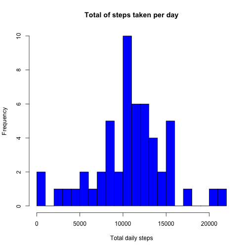

```r
hist(steps.aggr.date$x, xlab = "Total daily steps", breaks = 20, main = "Total of steps taken per day", col="blue")
```

### Calculate and report the mean and median of the total number of steps taken per day

```r
mean(steps.aggr.date$x)
```

```
## [1] 10766.19
```

```r
median(steps.aggr.date$x)
```

```
## [1] 10765
```

## Part II: What is the average daily activity pattern?

–> Make a new data.frame with the steps aggregated by interval

```r
# Aggregate the number of steps by the interval
steps.aggr.int <- aggregate(x=steps_2$steps, by=list(steps_2$interval), FUN=mean)

# Change the column names of the resulting data frame
colnames(steps.aggr.int) <- c("Interval","Average.Steps")

# View the resulting dataframe
head(steps.aggr.int, 5)
```

```
##   Interval Average.Steps
## 1        0     1.7169811
## 2        5     0.3396226
## 3       10     0.1320755
## 4       15     0.1509434
## 5       20     0.0754717
```

### Make a time series plot (i.e. type = “l”) of the 5-minute interval (x-axis) and the average number of steps taken, averaged across all days (y-axis)

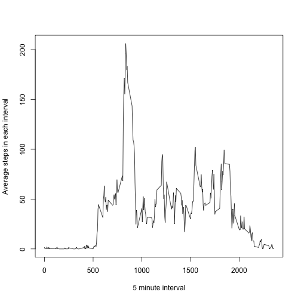

```r
# Plot the chart as a time series
plot(steps.aggr.int$Interval, steps.aggr.int$Average.Steps, type="l", xlab="5 minute interval", ylab="Average steps in each interval")
```

### Which 5-minute interval, on average across all the days in the dataset, contains the maximum number of steps?

```r
steps.aggr.int[which.max(steps.aggr.int$Average.Steps),]
```

```
##     Interval Average.Steps
## 104      835      206.1698
```